# Classification Non Supevisée , cours 1

Anna Mathieu

2025-11-11

## Récupération des données

```r
library(FactoMineR)
data("decathlon")
data <- decathlon
data <- data[,1:10]

summary(data)
```

```
##       100m         Long.jump       Shot.put       High.jump          400m
##  Min.   :10.44   Min.   :6.61   Min.   :12.68   Min.   :1.850   Min.   :46.81
##  1st Qu.:10.85   1st Qu.:7.03   1st Qu.:13.88   1st Qu.:1.920   1st Qu.:48.93
##  Median :10.98   Median :7.30   Median :14.57   Median :1.950   Median :49.40
##  Mean   :11.00   Mean   :7.26   Mean   :14.48   Mean   :1.977   Mean   :49.62
##  3rd Qu.:11.14   3rd Qu.:7.48   3rd Qu.:14.97   3rd Qu.:2.040   3rd Qu.:50.30
##  Max.   :11.64   Max.   :7.96   Max.   :16.36   Max.   :2.150   Max.   :53.20
##   110m.hurdle        Discus        Pole.vault       Javeline
##  Min.   :13.97   Min.   :37.92   Min.   :4.200   Min.   :50.31
##  1st Qu.:14.21   1st Qu.:41.90   1st Qu.:4.500   1st Qu.:55.27
##  Median :14.48   Median :44.41   Median :4.800   Median :58.36
##  Mean   :14.61   Mean   :44.33   Mean   :4.762   Mean   :58.32
##  3rd Qu.:14.98   3rd Qu.:46.07   3rd Qu.:4.920   3rd Qu.:60.89
##  Max.   :15.67   Max.   :51.65   Max.   :5.400   Max.   :70.52
##      1500m
##  Min.   :262.1
##  1st Qu.:271.0
##  Median :278.1
##  Mean   :279.0
##  3rd Qu.:285.1
##  Max.   :317.0
```

Calcul du vecteur des moyennes par calcul matriciel

```r
moy_matr <- matrix(1, nrow = nrow(data), ncol = ncol(data) ) # construction de la matrice des moyennes de dimension n (41) x p (10)

# transforme data en matrice
data <- as.matrix(data)

# création de la matrice NxP des moyennes
for (i in 1:nrow(data)) {
  moy_col <- colMeans(data) #  récupération des moyennes par colonne de data
  moy_matr[i,] <- moy_col   #  chaque colonne p(i) contient la moyenne de la colonne  i
}

# Création de la matrice X centrée => X_Centrée = X (=data) - X_moyenne (=moy_matr)
X_centree = data - moy_matr

# test : data[1,1] - 11

X_centree # dim N * P
```

```
##                    100m Long.jump     Shot.put    High.jump        400m
## SEBRLE       0.04195122      0.32  0.352926829  0.093170732  0.19365854
## CLAY        -0.23804878      0.14 -0.217073171 -0.116829268 -0.24634146
## KARPOV       0.02195122      0.04  0.292926829  0.063170732 -1.24634146
## BERNARD      0.02195122     -0.03 -0.227073171 -0.056829268 -0.68634146
## YURKOV       0.34195122     -0.17  0.712926829  0.123170732  0.80365854
## WARNERS      0.11195122      0.34 -0.167073171  0.003170732 -0.93634146
## ZSIVOCZKY    0.13195122      0.04 -0.997073171  0.033170732 -0.99634146
## McMULLEN    -0.16804878      0.05 -0.717073171  0.153170732  0.29365854
## MARTINEAU    0.64195122     -0.45  0.092926829 -0.026829268  0.52365854
## HERNU        0.37195122      0.30 -0.067073171 -0.116829268  1.48365854
## BARRAS       0.33195122     -0.29 -0.387073171 -0.026829268 -0.13634146
## NOOL         0.33195122      0.01 -1.797073171  0.003170732 -0.41634146
## BOURGUIGNON  0.36195122     -0.46 -1.017073171 -0.116829268  1.54365854
## Sebrle      -0.14804878      0.58  1.882926829  0.143170732 -1.25634146
## Clay        -0.55804878      0.70  0.752926829  0.083170732 -0.42634146
## Karpov      -0.49804878      0.55  1.452926829  0.113170732 -2.80634146
## Macey       -0.10804878      0.21  1.252926829  0.173170732 -0.64634146
## Warners     -0.37804878      0.48  0.002926829 -0.006829268 -1.64634146
## Zsivoczky   -0.08804878     -0.12  0.832926829  0.143170732 -0.21634146
## Hernu       -0.02804878     -0.07  0.172926829  0.053170732 -0.88634146
## Nool        -0.19804878      0.27 -0.217073171 -0.096829268 -0.80634146
## Bernard     -0.30804878      0.22  0.322926829  0.143170732 -0.48634146
## Schwarzl    -0.01804878      0.23 -0.467073171 -0.036829268  0.14365854
## Pogorelov   -0.04804878      0.05  0.622926829  0.083170732  1.17365854
## Schoenbeck  -0.09804878      0.04  0.292926829 -0.096829268  0.68365854
## Barras       0.14195122     -0.27  0.432926829 -0.036829268 -0.20634146
## Smith       -0.14804878     -0.45  0.762926829 -0.066829268 -0.34634146
## Averyanov   -0.44804878      0.08 -0.037073171 -0.036829268  0.10365854
## Ojaniemi    -0.31804878      0.24  0.492926829 -0.036829268 -0.49634146
## Smirnov     -0.10804878     -0.19 -0.597073171 -0.036829268 -0.50634146
## Qi           0.06195122      0.08 -0.927073171 -0.006829268  0.03365854
## Drews       -0.12804878      0.12 -1.407073171 -0.096829268 -1.10634146
## Parkhomenko  0.14195122     -0.65  1.212926829  0.053170732  1.42365854
## Terek       -0.07804878     -0.32  0.672926829 -0.036829268 -0.05634146
## Gomez        0.08195122      0.00  0.092926829 -0.126829268 -1.00634146
## Turi         0.08195122     -0.35 -0.857073171  0.053170732  2.05365854
## Lorenzo      0.10195122     -0.23 -1.257073171 -0.126829268 -0.27634146
## Karlivans    0.33195122      0.00 -1.177073171 -0.006829268  0.92365854
## Korkizoglou -0.13804878     -0.19  0.332926829 -0.036829268  1.54365854
```

[output cut: 29 more lines]

```
## Smith       -0.59585366  4.69439024 -0.56243902  3.20341463  -6.284878
## Averyanov   -0.21585366 -4.44560976  0.03756098 -3.80658537  -8.004878
## Ojaniemi     0.40414634 -3.97560976 -0.16243902  0.94341463  -3.314878
## Smirnov      0.16414634 -1.85560976 -0.06243902  2.56341463 -15.714878
## Qi           0.17414634  0.80439024 -0.26243902  2.47341463  -6.394878
## Drews       -0.59585366 -4.21560976  0.23756098 -6.78658537  -4.814878
## Parkhomenko  0.27414634 -2.42560976  0.03756098  7.50341463  -1.084878
## Terek        0.51414634  1.29439024  0.53756098 -7.69658537  11.335122
## Gomez       -0.19585366 -3.37560976 -0.36243902  2.39341463  -9.324878
## Turi        -0.34585366 -4.49560976  0.03756098  1.02341463  10.985122
## Lorenzo      0.77414634 -4.10560976 -0.26243902  0.04341463 -15.944878
## Karlivans    0.37414634 -0.98560976 -0.26243902 -5.39658537  -0.354878
## Korkizoglou  0.35414634  1.74439024 -0.06243902 -5.26658537  37.975122
## Uldal        0.48414634 -1.31560976 -0.26243902  1.68341463   2.675122
## Casarsa      0.78414634  4.33439024 -0.36243902  0.30341463  17.095122
```

Calcul de la Matrice des Variances covariance X’X

```r
# Initialisation de la matrice des var covariance : de dim p x p
varcov_matr <- matrix(1, nrow = ncol(data), ncol = ncol(data))

get.covariance <- function (x1, x2, X) {
  # x1: variable 1 (n° col de X)
  # x2 : variable 2 (n° de col de X)
  # X : matrice centrée

  cov = 0
  sum = 0

  for (i in 1:nrow(X)) {
    sum = sum + (X[i,x1] * X[i,x2])
    # print(sum)
  }

  cov = sum/(nrow(X)-1)
  return(cov)
}
```

test de la formule

```r
# Test de la formule : avec cov(X1,X1)
res <- get.covariance(x1 = 1, x2 = 1, X = X_centree)
res # 0.0691811
```

```
## [1] 0.0691811
```

```r
# variance de la variable "100m"
var(X_centree[,1]) # 0.0691811
```

```
## [1] 0.0691811
```

```r
cov(X_centree[,1], X_centree[,1]) # 0.0691811
```

```
## [1] 0.0691811
```

```r
# Test de la formule avec cov(X1,X2)
res <- get.covariance(x1 = 1, x2 = 2, X_centree)
res # -0.0498225
```

```
## [1] -0.0498225
```

```r
cov(X_centree[,1], X_centree[,2]) # [1] -0.0498225
```

```
## [1] -0.0498225
```

```r
# Remplissage de la matrice

for (i in 1:ncol(X_centree)) {
  for(j in 1:ncol(X_centree)){

    varcov_matr[i,j] <- get.covariance(x1 = i, x2 = j, X_centree)
  }
}

dim(varcov_matr)
```

```
## [1] 10 10
```

```r
varcov_matr
```

```
##               [,1]       [,2]        [,3]         [,4]        [,5]
##  [1,]  0.069181098 -0.0498225 -0.07730085 -0.005761341  0.15785018
##  [2,] -0.049822500  0.1001100  0.04781500  0.008292500 -0.21972500
##  [3,] -0.077300854  0.0478150  0.67968122  0.035875488 -0.13164098
##  [4,] -0.005761341  0.0082925  0.03587549  0.007912195 -0.01928439
##  [5,]  0.157850183 -0.2197250 -0.13164098 -0.019284390  1.33044878
##  [6,]  0.071959207 -0.0754450 -0.09786744 -0.011888476  0.29820695
##  [7,] -0.196976280  0.2076700  1.71478433  0.110935732 -0.45927896
##  [8,] -0.006035122  0.0179450  0.01402232 -0.003862073 -0.02542585
##  [9,] -0.200269329  0.1828975  1.49208476  0.073796402  0.02356220
## [10,] -0.185897744 -0.1244175  1.11445963 -0.046624146  5.49495579
##                [,6]       [,7]          [,8]         [,9]        [,10]
##  [1,]  0.0719592073 -0.1969763 -0.0060351220  -0.20026933  -0.18589774
##  [2,] -0.0754450000  0.2076700  0.0179450000   0.18289750  -0.12441750
##  [3,] -0.0978674390  1.7147843  0.0140223171   1.49208476   1.11445963
##  [4,] -0.0118884756  0.1109357 -0.0038620732   0.07379640  -0.04662415
##  [5,]  0.2982069512 -0.4592790 -0.0254258537   0.02356220   5.49495579
##  [6,]  0.2225848780 -0.5198437 -0.0003546341   0.01991049   0.20674573
##  [7,] -0.5198436585 11.4098352 -0.1409240244   2.57427463  10.17995195
##  [8,] -0.0003546341 -0.1409240  0.0772839024  -0.04025646   0.80300780
##  [9,]  0.0199104878  2.5742746 -0.0402564634  23.29819305 -10.16419043
## [10,]  0.2067457317 10.1799520  0.8030078049 -10.16419043 136.26470061
```

On a obtenu la matrice des covariances, qui contient dans sa trace (diagonale), les variances des variables 1 à 10.

On va calculer à partir de cette matrice la matrice des r (coefficients de corrélation de Pearson) par la formule :

p(x,y) = cov / (sqrt(x) * sqrt(y))

```r
# Calcul de la matrice des r

coeff_cor <- matrix(0, nrow = 10, ncol = 10)

for (i in 1:ncol(varcov_matr)) {
  for (j in 1:ncol(varcov_matr)) {



    coeff_cor[i,j] <- varcov_matr[i,j] / (sqrt(varcov_matr[i,i]*varcov_matr[j,j]))


  }
}
coeff_cor
```

```
##              [,1]        [,2]        [,3]        [,4]         [,5]         [,6]
##  [1,]  1.00000000 -0.59867767 -0.35648227 -0.24625292  0.520298155  0.579888931
##  [2,] -0.59867767  1.00000000  0.18330436  0.29464444 -0.602062618 -0.505410086
##  [3,] -0.35648227  0.18330436  1.00000000  0.48921153 -0.138432919 -0.251615714
##  [4,] -0.24625292  0.29464444  0.48921153  1.00000000 -0.187956928 -0.283289090
##  [5,]  0.52029815 -0.60206262 -0.13843292 -0.18795693  1.000000000  0.547987756
##  [6,]  0.57988893 -0.50541009 -0.25161571 -0.28328909  0.547987756  1.000000000
##  [7,] -0.22170757  0.19431009  0.61576810  0.36921834 -0.117879365 -0.326200961
##  [8,] -0.08253683  0.20401411  0.06118185 -0.15618074 -0.079292469 -0.002703885
##  [9,] -0.15774645  0.11975893  0.37495551  0.17188009  0.004232096  0.008743251
## [10,] -0.06054645 -0.03368613  0.11580306 -0.04490252  0.408106432  0.037540240
##             [,7]         [,8]         [,9]       [,10]
##  [1,] -0.2217076 -0.082536834 -0.157746452 -0.06054645
##  [2,]  0.1943101  0.204014112  0.119758933 -0.03368613
##  [3,]  0.6157681  0.061181853  0.374955509  0.11580306
##  [4,]  0.3692183 -0.156180742  0.171880092 -0.04490252
##  [5,] -0.1178794 -0.079292469  0.004232096  0.40810643
##  [6,] -0.3262010 -0.002703885  0.008743251  0.03754024
##  [7,]  1.0000000 -0.150072400  0.157889799  0.25817510
##  [8,] -0.1500724  1.000000000 -0.030000603  0.24744778
##  [9,]  0.1578898 -0.030000603  1.000000000 -0.18039313
## [10,]  0.2581751  0.247447780 -0.180393128  1.00000000
```

```r
# il y a bien des 1 en diagonales : coeff de corrélation de 1 entre une variable et elle meme

# test cor(x1,x2)
# cor(X_centree[,1], X_centree[,2])
```

Calcul de la matrice des r² : Carré de la matrice ‘coeff_cor’

```r
coeff_cor <- coeff_cor^2
```

Calcul de la matrice de distance: (1 - r²)

```r
dist_matr <- 1-coeff_cor
dist_matr
```

```
##            [,1]      [,2]      [,3]      [,4]      [,5]      [,6]      [,7]
##  [1,] 0.0000000 0.6415850 0.8729204 0.9393595 0.7292898 0.6637288 0.9508458
##  [2,] 0.6415850 0.0000000 0.9663995 0.9131847 0.6375206 0.7445606 0.9622436
##  [3,] 0.8729204 0.9663995 0.0000000 0.7606721 0.9808363 0.9366895 0.6208297
##  [4,] 0.9393595 0.9131847 0.7606721 0.0000000 0.9646722 0.9197473 0.8636778
##  [5,] 0.7292898 0.6375206 0.9808363 0.9646722 0.0000000 0.6997094 0.9861045
##  [6,] 0.6637288 0.7445606 0.9366895 0.9197473 0.6997094 0.0000000 0.8935929
##  [7,] 0.9508458 0.9622436 0.6208297 0.8636778 0.9861045 0.8935929 0.0000000
##  [8,] 0.9931877 0.9583782 0.9962568 0.9756076 0.9937127 0.9999927 0.9774783
##  [9,] 0.9751161 0.9856578 0.8594084 0.9704572 0.9999821 0.9999236 0.9750708
## [10,] 0.9963341 0.9988652 0.9865897 0.9979838 0.8334491 0.9985907 0.9333456
##            [,8]      [,9]     [,10]
##  [1,] 0.9931877 0.9751161 0.9963341
##  [2,] 0.9583782 0.9856578 0.9988652
##  [3,] 0.9962568 0.8594084 0.9865897
##  [4,] 0.9756076 0.9704572 0.9979838
##  [5,] 0.9937127 0.9999821 0.8334491
##  [6,] 0.9999927 0.9999236 0.9985907
##  [7,] 0.9774783 0.9750708 0.9333456
##  [8,] 0.0000000 0.9991000 0.9387696
##  [9,] 0.9991000 0.0000000 0.9674583
## [10,] 0.9387696 0.9674583 0.0000000
```

Par calcul matriciel, nous avons donc pu calculer la matrice des distances, correspondant à la matrice des 1-r² (r² = coefficients de corrélation)

Deux variables sont d’autant plus proches que leurs coefficients de distances sont proches. Deux variables identiques ont une corrélation de 1, et sont donc complètement confondues, il y a entre elles une distance nulle.

## Clustering des variables

```r
# on change le nom des cols et des rows
names <- names(decathlon)[1:10]
colnames(dist_matr)<- names
rownames(dist_matr)<- names
```

PCA de la matrice de distance

```r
res.pca <- PCA(dist_matr)
```

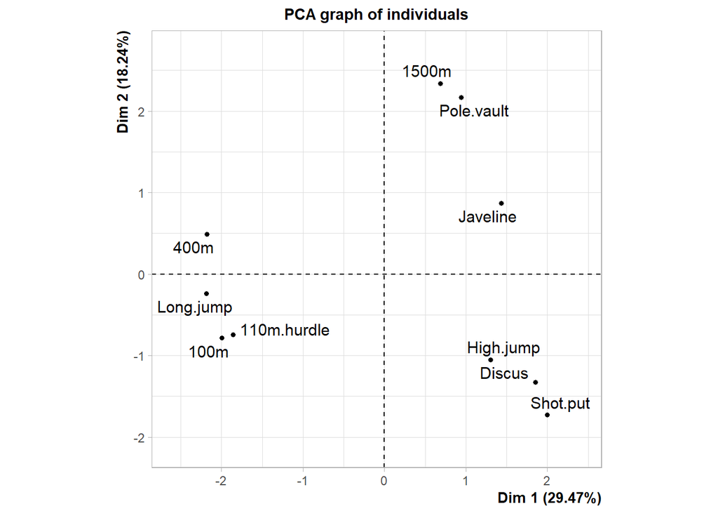

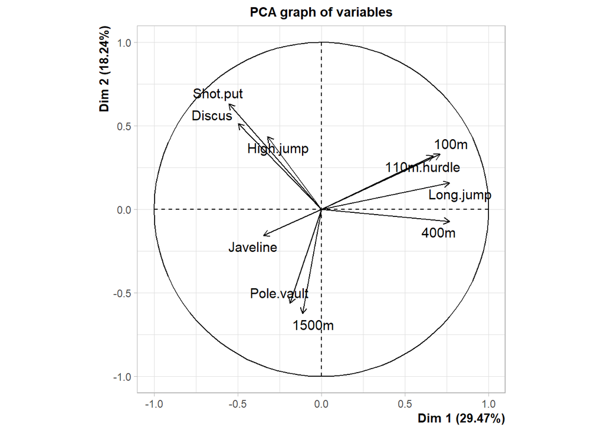

Avec la PCA sur la matrice des distances entre les variables du jeu de données (interprétées comme des individus), on peut voir qu’il y a 3 clusters distincts de variables. On peut réaliser une classification ascendante hierarchique (HCPC) à partir afin de séparer les variables en 3 clusters.

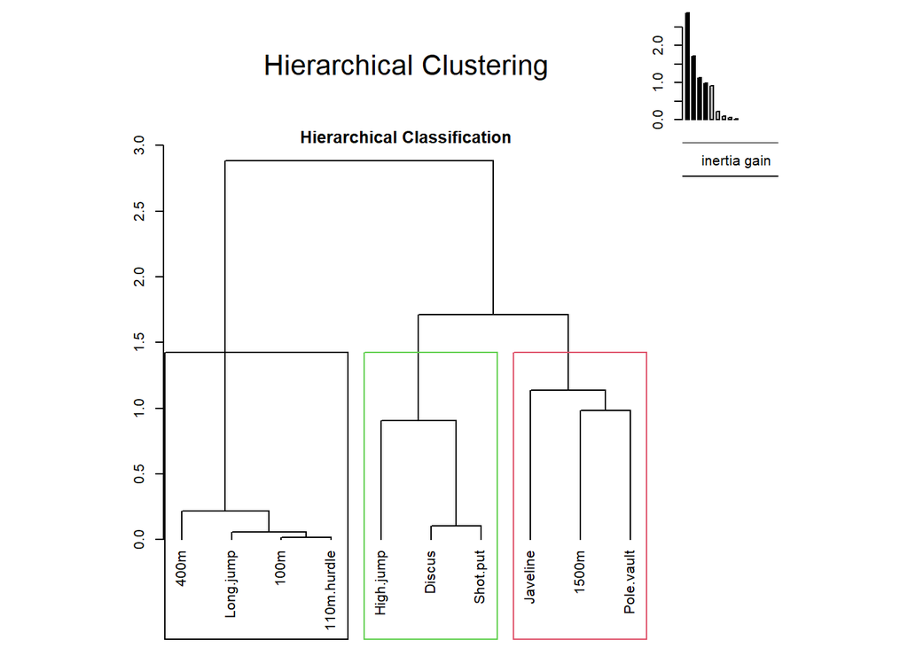

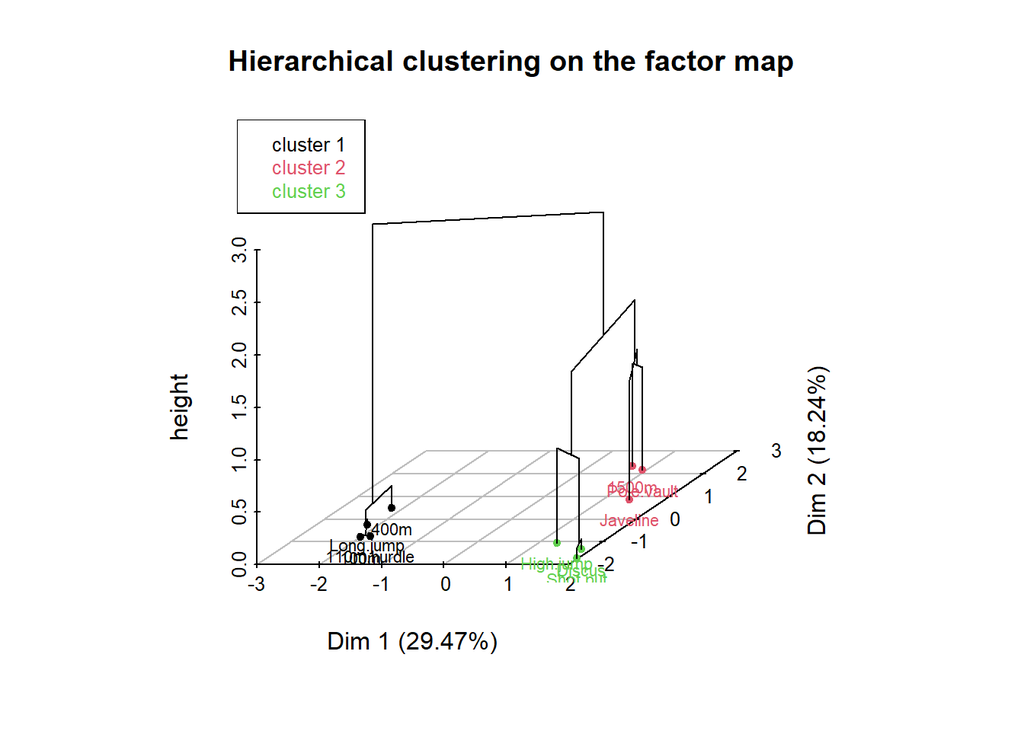

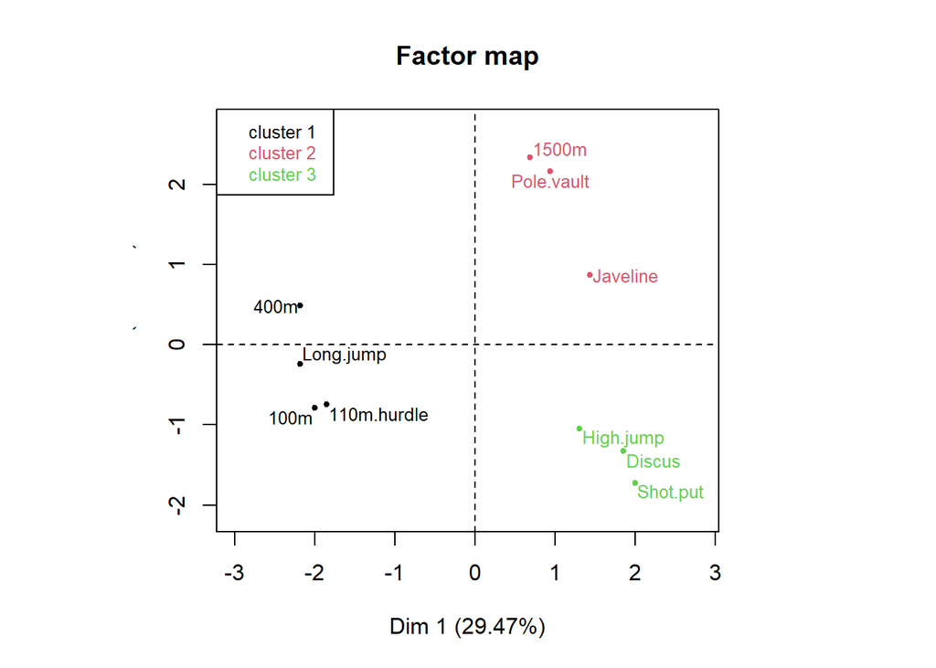

```
## **Results for the Hierarchical Clustering on Principal Components**
##    name
## 1  "$data.clust"
## 2  "$desc.var"
## 3  "$desc.var$quanti.var"
## 4  "$desc.var$quanti"
## 5  "$desc.axes"
## 6  "$desc.axes$quanti.var"
## 7  "$desc.axes$quanti"
## 8  "$desc.ind"
## 9  "$desc.ind$para"
## 10 "$desc.ind$dist"
## 11 "$call"
## 12 "$call$t"
##    description
## 1  "dataset with the cluster of the individuals"
## 2  "description of the clusters by the variables"
## 3  "description of the cluster var. by the continuous var."
## 4  "description of the clusters by the continuous var."
## 5  "description of the clusters by the dimensions"
## 6  "description of the cluster var. by the axes"
## 7  "description of the clusters by the axes"
## 8  "description of the clusters by the individuals"
## 9  "parangons of each clusters"
## 10 "specific individuals"
## 11 "summary statistics"
## 12 "description of the tree"
```

```r
HCPC(res.pca, nb.clust = 3)
```

Les clusters identifiés sont : - 400 m, long jump, 110 m hurdle [110 m haies], 100 m - high jump [saut en hauteur], discus [lancer de disque], shot put [lancer de poids] - 1500 m, pole vault [saut à la perche], javeline [lancer de javelot]

Interprétation des clusters : Les clusters regroupent des variables (épreuves de décathlon) qui se ressemblent, c’est-à-dire pour lesquelles les mêmes individus obtiennent des résultats similaires. Les individus réussissent similairement sur des épreuves similaires pour leur profil sportif, ce qui permet de regrouper les épreuves ensemble par similarité entre elles.

Le cluster 1 regroupe les épreuves de 400 m, saut en longueur, 100 m et 110 m haies. Ces épreuves sont des épreuves de vitesse et ce qui peuvent les rassembler ce sont qu’elles sont bien réussies par des sportifs vifs, impulsifs, ce sont des épreuves de vitesse / explosivité, car elles requièrent une vitesse explosive et une puissance anaérobie.